# DATA 607 Assignment 5A - Airline Delays

Muntasir Mehran

2026-10-05

## Airline Delay Data

The given data had arrival information for Alaska Airlines and AM West throughout five destinations. I first recreated the data in a wide form alike to the original source table.

```r
airline_data <- data.frame(
  Airline = c("ALASKA", "", "AM WEST", ""),
  Status = c("on time", "delayed", "on time", "delayed"),
  Los_Angeles = c(497, 62, 694, 117),
  Phoenix = c(221, 12, 4840, 415),
  San_Diego = c(212, 20, 383, 65),
  San_Francisco = c(503, 102, 320, 129),
  Seattle = c(1841, 305, 201, 61)
)

airline_data
```

```
##   Airline  Status Los_Angeles Phoenix San_Diego San_Francisco Seattle
## 1  ALASKA on time         497     221       212           503    1841
## 2         delayed          62      12        20           102     305
## 3 AM WEST on time         694    4840       383           320     201
## 4         delayed         117     415        65           129      61
```

```r
write.csv(airline_data, "airline_delays.csv", row.names = FALSE)
```

## Reading CSV

I plan to read the CSV file into R in order to clean and tranform the data.

```r
airline_raw <- read.csv("airline_delays.csv")

airline_raw
```

```
##   Airline  Status Los_Angeles Phoenix San_Diego San_Francisco Seattle
## 1  ALASKA on time         497     221       212           503    1841
## 2         delayed          62      12        20           102     305
## 3 AM WEST on time         694    4840       383           320     201
## 4         delayed         117     415        65           129      61
```

## Clean Vacant Ariline Names

The given table has vacancies on the airline name on each delayed row because the airline name is implied by the row above it. I converted these blank values to missing values and then filled them using the aforementioned airline name.

```r
library(dplyr)
library(tidyr)

airline_clean <- airline_raw %>%
  mutate(Airline = na_if(Airline, "")) %>%
  fill(Airline)

airline_clean
```

```
##   Airline  Status Los_Angeles Phoenix San_Diego San_Francisco Seattle
## 1  ALASKA on time         497     221       212           503    1841
## 2  ALASKA delayed          62      12        20           102     305
## 3 AM WEST on time         694    4840       383           320     201
## 4 AM WEST delayed         117     415        65           129      61
```

## Tranformation - wide to long

To make tidy the data, I have to transform the five destination columns into two variable - destination city & # of flights.

```r
airline_long <- airline_clean %>%
  pivot_longer(
    cols = Los_Angeles:Seattle,
    names_to = "City",
    values_to = "Flights"
  )

airline_long
```

```
## # A tibble: 20 × 4
##    Airline Status  City          Flights
##    <chr>   <chr>   <chr>           <int>
##  1 ALASKA  on time Los_Angeles       497
##  2 ALASKA  on time Phoenix           221
##  3 ALASKA  on time San_Diego         212
##  4 ALASKA  on time San_Francisco     503
##  5 ALASKA  on time Seattle          1841
##  6 ALASKA  delayed Los_Angeles        62
##  7 ALASKA  delayed Phoenix            12
##  8 ALASKA  delayed San_Diego          20
##  9 ALASKA  delayed San_Francisco     102
## 10 ALASKA  delayed Seattle           305
## 11 AM WEST on time Los_Angeles       694
## 12 AM WEST on time Phoenix          4840
## 13 AM WEST on time San_Diego         383
## 14 AM WEST on time San_Francisco     320
## 15 AM WEST on time Seattle           201
## 16 AM WEST delayed Los_Angeles       117
## 17 AM WEST delayed Phoenix           415
## 18 AM WEST delayed San_Diego          65
## 19 AM WEST delayed San_Francisco     129
## 20 AM WEST delayed Seattle            61
```

## Airline Analysis

I first compared the general percentage of delayed flights for every airline. Utilizing percentages unstead of just counts makes for a more compelling comparison since the airlines contain distinct total flight counts.

```r
overall_delays <- airline_long %>%
  group_by(Airline, Status) %>%
  summarise(Flights = sum(Flights), .groups = "drop") %>%
  group_by(Airline) %>%
  mutate(Percentage = Flights / sum(Flights) * 100)

overall_delays
```

```
## # A tibble: 4 × 4
## # Groups:   Airline [2]
##   Airline Status  Flights Percentage
##   <chr>   <chr>     <int>      <dbl>
## 1 ALASKA  delayed     501       13.3
## 2 ALASKA  on time    3274       86.7
## 3 AM WEST delayed     787       10.9
## 4 AM WEST on time    6438       89.1
```

In general, Alaska had a delay rate of about 13.27 % wheras AM West had a delay rate of about 10.89%. From this reading, AM West is apparently better due to a more efficent timing.

#Delay Rates Across Cities

```r
city_delays <- airline_long %>%
  group_by(Airline, City) %>%
  mutate(
    Total_Flights = sum(Flights),
    Percentage = Flights / Total_Flights * 100
  ) %>%
  filter(Status == "delayed") %>%
  select(Airline, City, Flights, Total_Flights, Percentage)

city_delays
```

```
## # A tibble: 10 × 5
## # Groups:   Airline, City [10]
##    Airline City          Flights Total_Flights Percentage
##    <chr>   <chr>           <int>         <int>      <dbl>
##  1 ALASKA  Los_Angeles        62           559      11.1
##  2 ALASKA  Phoenix            12           233       5.15
##  3 ALASKA  San_Diego          20           232       8.62
##  4 ALASKA  San_Francisco     102           605      16.9
##  5 ALASKA  Seattle           305          2146      14.2
##  6 AM WEST Los_Angeles       117           811      14.4
##  7 AM WEST Phoenix           415          5255       7.90
##  8 AM WEST San_Diego          65           448      14.5
##  9 AM WEST San_Francisco     129           449      28.7
## 10 AM WEST Seattle            61           262      23.3
```

[output not shown]

## Added Visual

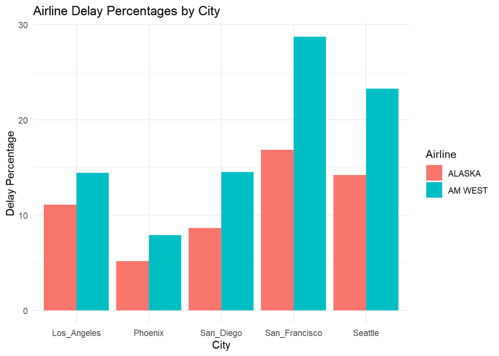

```r
library(ggplot2)

ggplot(city_delays, aes(x = City, y = Percentage, fill = Airline)) +
  geom_col(position = "dodge") +
  labs(
    title = "Airline Delay Percentages by City",
    x = "City",
    y = "Delay Percentage"
  ) +
  theme_minimal()
```

## Conclusion

Ultimately, the percentages provides ample telling of AM West’s delay rate. Around 10.89% of AM West flights were delayed compared to about 13.27% of Alaska flights. Looking at the general results, AM West seems to have done better. Taking a more urban focus showcases that Alaska had a lower delay percentage than AM West in all 5 spots. This implies that overall percentages don’t give the clear picture. The difference essentially comes from hwo flights are distributed throughout cities. AM West contained a plethora of flights in Phoeniz, where delay rates were more or less low, while Alaska contained numerous flights in Seattle, where the delay rates were noticeably greater.